# Laboratorio7_DS

### Universidad del Valle de Guatemala Data Science Laboratorio 7

#### Integrantes: - Christopher García 20541 - Andrea Lam 20102

```python
import pandas as pd
import numpy as np
import seaborn as sns
import matplotlib.pyplot as plt

import warnings
warnings.filterwarnings('ignore')
```

```python
!pip install -U ipykernel
!pip install -U pip
!pip install -U setuptools wheel
!pip install -U "mxnet<2.0.0"
!pip install autogluon --no-cache-dir
```

[output not shown]

[output not shown]

```python
from autogluon.tabular import TabularDataset, TabularPredictor
```

```python
diabetes = pd.read_csv('diabetes.csv')
```

#### Análisis exploratorio (EDA)

```python
diabetes
```

|  | Pregnancies | Glucose | BloodPressure | SkinThickness | Insulin | BMI | DiabetesPedigreeFunction | Age | Outcome |
| --- | --- | --- | --- | --- | --- | --- | --- | --- | --- |
| 0 | 6 | 148 | 72 | 35 | 0 | 33.6 | 0.627 | 50 | 1 |
| 1 | 1 | 85 | 66 | 29 | 0 | 26.6 | 0.351 | 31 | 0 |
| 2 | 8 | 183 | 64 | 0 | 0 | 23.3 | 0.672 | 32 | 1 |
| 3 | 1 | 89 | 66 | 23 | 94 | 28.1 | 0.167 | 21 | 0 |
| 4 | 0 | 137 | 40 | 35 | 168 | 43.1 | 2.288 | 33 | 1 |
| ... | ... | ... | ... | ... | ... | ... | ... | ... | ... |
| 763 | 10 | 101 | 76 | 48 | 180 | 32.9 | 0.171 | 63 | 0 |
| 764 | 2 | 122 | 70 | 27 | 0 | 36.8 | 0.340 | 27 | 0 |
| 765 | 5 | 121 | 72 | 23 | 112 | 26.2 | 0.245 | 30 | 0 |
| 766 | 1 | 126 | 60 | 0 | 0 | 30.1 | 0.349 | 47 | 1 |
| 767 | 1 | 93 | 70 | 31 | 0 | 30.4 | 0.315 | 23 | 0 |

768 rows × 9 columns

```python
diabetes.head(5)
```

|  | Pregnancies | Glucose | BloodPressure | SkinThickness | Insulin | BMI | DiabetesPedigreeFunction | Age | Outcome |
| --- | --- | --- | --- | --- | --- | --- | --- | --- | --- |
| 0 | 6 | 148 | 72 | 35 | 0 | 33.6 | 0.627 | 50 | 1 |
| 1 | 1 | 85 | 66 | 29 | 0 | 26.6 | 0.351 | 31 | 0 |
| 2 | 8 | 183 | 64 | 0 | 0 | 23.3 | 0.672 | 32 | 1 |
| 3 | 1 | 89 | 66 | 23 | 94 | 28.1 | 0.167 | 21 | 0 |
| 4 | 0 | 137 | 40 | 35 | 168 | 43.1 | 2.288 | 33 | 1 |

```python
diabetes.tail(5)
```

|  | Pregnancies | Glucose | BloodPressure | SkinThickness | Insulin | BMI | DiabetesPedigreeFunction | Age | Outcome |
| --- | --- | --- | --- | --- | --- | --- | --- | --- | --- |
| 763 | 10 | 101 | 76 | 48 | 180 | 32.9 | 0.171 | 63 | 0 |
| 764 | 2 | 122 | 70 | 27 | 0 | 36.8 | 0.340 | 27 | 0 |
| 765 | 5 | 121 | 72 | 23 | 112 | 26.2 | 0.245 | 30 | 0 |
| 766 | 1 | 126 | 60 | 0 | 0 | 30.1 | 0.349 | 47 | 1 |
| 767 | 1 | 93 | 70 | 31 | 0 | 30.4 | 0.315 | 23 | 0 |

```python
diabetes.describe()
```

|  | Pregnancies | Glucose | BloodPressure | SkinThickness | Insulin | BMI | DiabetesPedigreeFunction | Age | Outcome |
| --- | --- | --- | --- | --- | --- | --- | --- | --- | --- |
| count | 768.000000 | 768.000000 | 768.000000 | 768.000000 | 768.000000 | 768.000000 | 768.000000 | 768.000000 | 768.000000 |
| mean | 3.845052 | 120.894531 | 69.105469 | 20.536458 | 79.799479 | 31.992578 | 0.471876 | 33.240885 | 0.348958 |
| std | 3.369578 | 31.972618 | 19.355807 | 15.952218 | 115.244002 | 7.884160 | 0.331329 | 11.760232 | 0.476951 |
| min | 0.000000 | 0.000000 | 0.000000 | 0.000000 | 0.000000 | 0.000000 | 0.078000 | 21.000000 | 0.000000 |
| 25% | 1.000000 | 99.000000 | 62.000000 | 0.000000 | 0.000000 | 27.300000 | 0.243750 | 24.000000 | 0.000000 |
| 50% | 3.000000 | 117.000000 | 72.000000 | 23.000000 | 30.500000 | 32.000000 | 0.372500 | 29.000000 | 0.000000 |
| 75% | 6.000000 | 140.250000 | 80.000000 | 32.000000 | 127.250000 | 36.600000 | 0.626250 | 41.000000 | 1.000000 |
| max | 17.000000 | 199.000000 | 122.000000 | 99.000000 | 846.000000 | 67.100000 | 2.420000 | 81.000000 | 1.000000 |

```python
diabetes.info()
```

```
<class 'pandas.core.frame.DataFrame'>
RangeIndex: 768 entries, 0 to 767
Data columns (total 9 columns):
 #   Column                    Non-Null Count  Dtype
---  ------                    --------------  -----
 0   Pregnancies               768 non-null    int64
 1   Glucose                   768 non-null    int64
 2   BloodPressure             768 non-null    int64
 3   SkinThickness             768 non-null    int64
 4   Insulin                   768 non-null    int64
 5   BMI                       768 non-null    float64
 6   DiabetesPedigreeFunction  768 non-null    float64
 7   Age                       768 non-null    int64
 8   Outcome                   768 non-null    int64
dtypes: float64(2), int64(7)
memory usage: 54.1 KB
```

```python
df_region = diabetes.groupby('Outcome').describe()
df_region
```

| Outcome | Pregnancies count | Pregnancies mean | Pregnancies std | Pregnancies min | Pregnancies 25% | Pregnancies 50% | Pregnancies 75% | Pregnancies max | Glucose count | Glucose mean | ... | DiabetesPedigreeFunction 75% | DiabetesPedigreeFunction max | Age count | Age mean | Age std | Age min | Age 25% | Age 50% | Age 75% | Age max |
| --- | --- | --- | --- | --- | --- | --- | --- | --- | --- | --- | --- | --- | --- | --- | --- | --- | --- | --- | --- | --- | --- |
| 0 | 500.0 | 3.298000 | 3.017185 | 0.0 | 1.00 | 2.0 | 5.0 | 13.0 | 500.0 | 109.980000 | ... | 0.56175 | 2.329 | 500.0 | 31.190000 | 11.667655 | 21.0 | 23.0 | 27.0 | 37.0 | 81.0 |
| 1 | 268.0 | 4.865672 | 3.741239 | 0.0 | 1.75 | 4.0 | 8.0 | 17.0 | 268.0 | 141.257463 | ... | 0.72800 | 2.420 | 268.0 | 37.067164 | 10.968254 | 21.0 | 28.0 | 36.0 | 44.0 | 70.0 |

2 rows × 64 columns

[figure not shown]

```python
sns.heatmap(diabetes.isnull(), yticklabels = False, cbar = False, cmap="Blues")
```

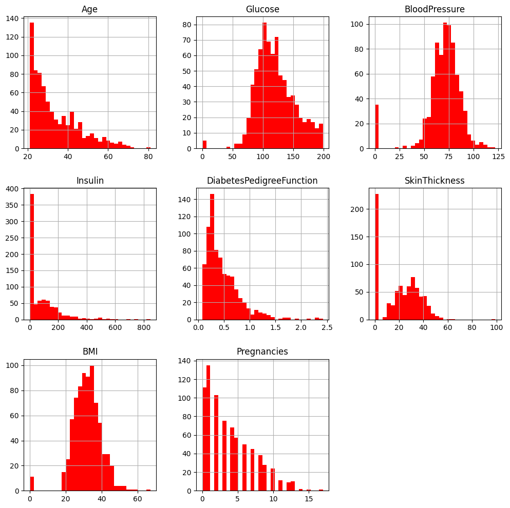

```python
diabetes[['Age', 'Glucose', 'BloodPressure', 'Insulin', 'DiabetesPedigreeFunction', 'SkinThickness', 'BMI', 'Pregnancies']].hist(bins = 30, figsize = (12, 12), color = 'r');
```

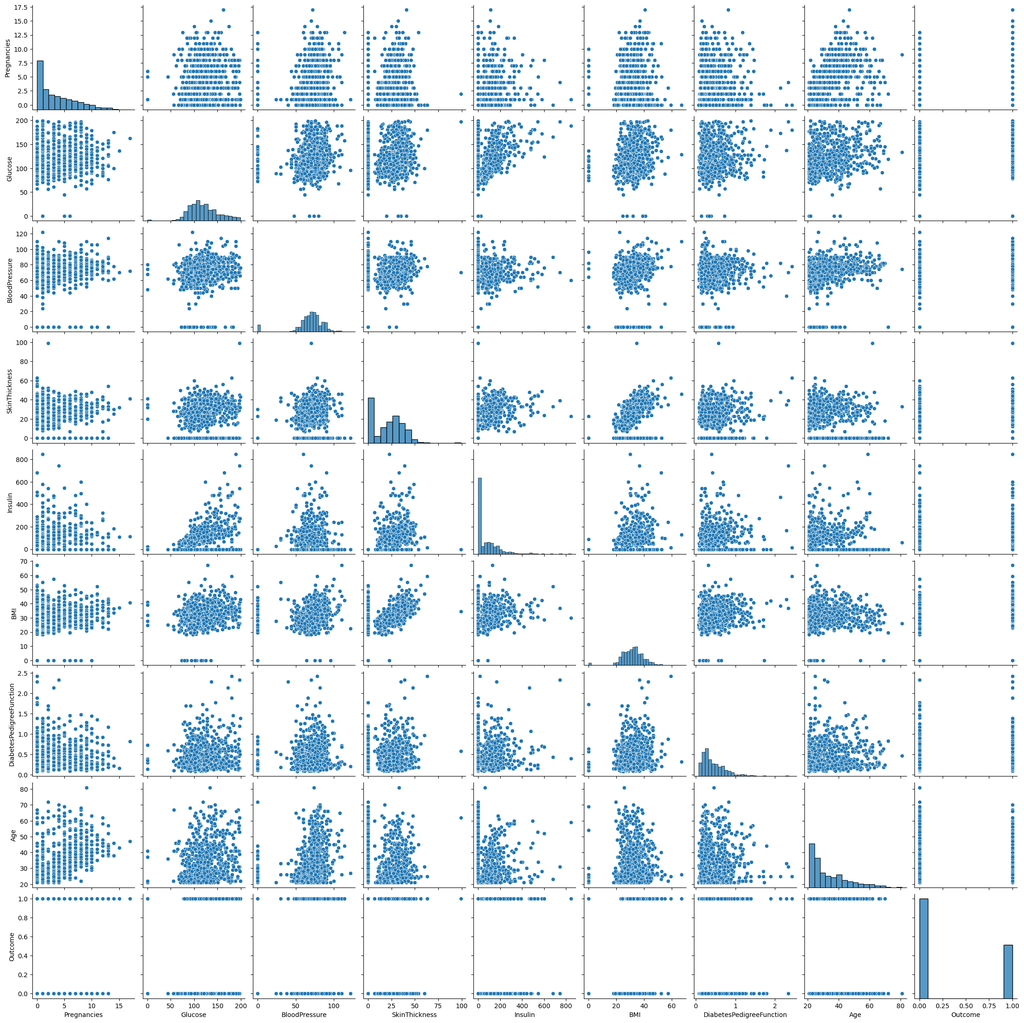

```python
sns.pairplot(diabetes)
```

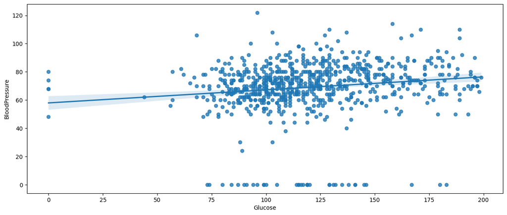

```python
plt.figure(figsize = (15, 6))
sns.regplot(x = 'Glucose', y = 'BloodPressure', data = diabetes)
plt.show()
```

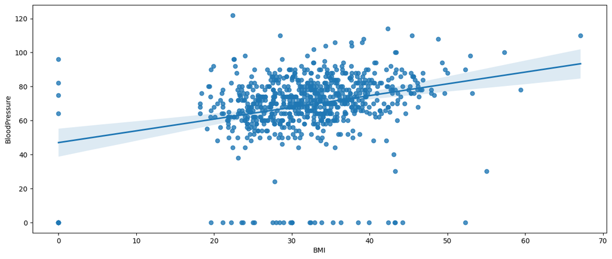

```python
plt.figure(figsize = (15, 6))
sns.regplot(x = 'BMI', y = 'BloodPressure', data = diabetes)
plt.show()
```

#### Entrenamiento

```python
from sklearn.model_selection import train_test_split
X_entreno, X_prueba = train_test_split(diabetes, test_size=0.2, random_state=0)
```

```python
X_entreno
```

|  | Pregnancies | Glucose | BloodPressure | SkinThickness | Insulin | BMI | DiabetesPedigreeFunction | Age | Outcome |
| --- | --- | --- | --- | --- | --- | --- | --- | --- | --- |
| 603 | 7 | 150 | 78 | 29 | 126 | 35.2 | 0.692 | 54 | 1 |
| 118 | 4 | 97 | 60 | 23 | 0 | 28.2 | 0.443 | 22 | 0 |
| 247 | 0 | 165 | 90 | 33 | 680 | 52.3 | 0.427 | 23 | 0 |
| 157 | 1 | 109 | 56 | 21 | 135 | 25.2 | 0.833 | 23 | 0 |
| 468 | 8 | 120 | 0 | 0 | 0 | 30.0 | 0.183 | 38 | 1 |
| ... | ... | ... | ... | ... | ... | ... | ... | ... | ... |
| 763 | 10 | 101 | 76 | 48 | 180 | 32.9 | 0.171 | 63 | 0 |
| 192 | 7 | 159 | 66 | 0 | 0 | 30.4 | 0.383 | 36 | 1 |
| 629 | 4 | 94 | 65 | 22 | 0 | 24.7 | 0.148 | 21 | 0 |
| 559 | 11 | 85 | 74 | 0 | 0 | 30.1 | 0.300 | 35 | 0 |
| 684 | 5 | 136 | 82 | 0 | 0 | 0.0 | 0.640 | 69 | 0 |

614 rows × 9 columns

```python
X_prueba
```

|  | Pregnancies | Glucose | BloodPressure | SkinThickness | Insulin | BMI | DiabetesPedigreeFunction | Age | Outcome |
| --- | --- | --- | --- | --- | --- | --- | --- | --- | --- |
| 661 | 1 | 199 | 76 | 43 | 0 | 42.9 | 1.394 | 22 | 1 |
| 122 | 2 | 107 | 74 | 30 | 100 | 33.6 | 0.404 | 23 | 0 |
| 113 | 4 | 76 | 62 | 0 | 0 | 34.0 | 0.391 | 25 | 0 |
| 14 | 5 | 166 | 72 | 19 | 175 | 25.8 | 0.587 | 51 | 1 |
| 529 | 0 | 111 | 65 | 0 | 0 | 24.6 | 0.660 | 31 | 0 |
| ... | ... | ... | ... | ... | ... | ... | ... | ... | ... |
| 476 | 2 | 105 | 80 | 45 | 191 | 33.7 | 0.711 | 29 | 1 |
| 482 | 4 | 85 | 58 | 22 | 49 | 27.8 | 0.306 | 28 | 0 |
| 230 | 4 | 142 | 86 | 0 | 0 | 44.0 | 0.645 | 22 | 1 |
| 527 | 3 | 116 | 74 | 15 | 105 | 26.3 | 0.107 | 24 | 0 |
| 380 | 1 | 107 | 72 | 30 | 82 | 30.8 | 0.821 | 24 | 0 |

154 rows × 9 columns

```python
predictor = TabularPredictor(label="Outcome",
                             problem_type='binary',  # Cambia a 'binary'
                             eval_metric='accuracy',  # Usa una métrica de clasificación
                             ).fit(train_data=X_entreno,
                                   time_limit=200,
                                   presets="best_quality")
```

[output not shown]

[output cut: 66 more lines]

[output not shown]

```python
predictor.fit_summary()
```

```
*** Summary of fit() ***
Estimated performance of each model:
                      model  score_val  pred_time_val   fit_time  pred_time_val_marginal  fit_time_marginal  stack_level  can_infer  fit_order
0       WeightedEnsemble_L2   0.793160       0.158455  44.677372                0.003081           1.952873            2       True         14
1    NeuralNetFastAI_BAG_L1   0.788274       0.112152  32.890708                0.112152          32.890708            1       True         10
2           CatBoost_BAG_L1   0.781759       0.010322  16.080908                0.010322          16.080908            1       True          7
3         LightGBMXT_BAG_L1   0.780130       0.015563  20.928442                0.015563          20.928442            1       True          3
4           LightGBM_BAG_L1   0.780130       0.019168  23.080157                0.019168          23.080157            1       True          4
5            XGBoost_BAG_L1   0.773616       0.043223   9.833790                0.043223           9.833790            1       True         11
6      LightGBMLarge_BAG_L1   0.763844       0.026220  23.984499                0.026220          23.984499            1       True         13
7     NeuralNetTorch_BAG_L1   0.763844       0.125980  26.441011                0.125980          26.441011            1       True         12
8   RandomForestEntr_BAG_L1   0.757329       0.186416   1.066143                0.186416           1.066143            1       True          6
9   RandomForestGini_BAG_L1   0.745928       0.222441   0.741224                0.222441           0.741224            1       True          5
10    ExtraTreesGini_BAG_L1   0.741042       0.212654   0.727877                0.212654           0.727877            1       True          8
11    ExtraTreesEntr_BAG_L1   0.739414       0.151340   0.815004                0.151340           0.815004            1       True          9
12    KNeighborsUnif_BAG_L1   0.700326       0.045170   0.044549                0.045170           0.044549            1       True          1
13    KNeighborsDist_BAG_L1   0.697068       0.042531   0.042352                0.042531           0.042352            1       True          2
Number of models trained: 14
Types of models trained:
{'StackerEnsembleModel_KNN', 'StackerEnsembleModel_RF', 'StackerEnsembleModel_XGBoost', 'StackerEnsembleModel_CatBoost', 'WeightedEnsembleModel', 'StackerEnsembleModel_TabularNeuralNetTorch', 'StackerEnsembleModel_NNFastAiTabular', 'StackerEnsembleModel_LGB', 'StackerEnsembleModel_XT'}
Bagging used: True  (with 6 folds)
Multi-layer stack-ensembling used: False
Feature Metadata (Processed):
(raw dtype, special dtypes):
('float', []) : 2 | ['BMI', 'DiabetesPedigreeFunction']
('int', [])   : 6 | ['Pregnancies', 'Glucose', 'BloodPressure', 'SkinThickness', 'Insulin', ...]
Plot summary of models saved to file: AutogluonModels/ag-20231014_034024/SummaryOfModels.html
*** End of fit() summary ***
```

[output not shown]

[output cut: 128 more lines]

[output not shown]

#### Evaluación de rendimiento

```python
predictor.leaderboard()
```

```
                      model  score_val  pred_time_val   fit_time  pred_time_val_marginal  fit_time_marginal  stack_level  can_infer  fit_order
0       WeightedEnsemble_L2   0.793160       0.158455  44.677372                0.003081           1.952873            2       True         14
1    NeuralNetFastAI_BAG_L1   0.788274       0.112152  32.890708                0.112152          32.890708            1       True         10
2           CatBoost_BAG_L1   0.781759       0.010322  16.080908                0.010322          16.080908            1       True          7
3         LightGBMXT_BAG_L1   0.780130       0.015563  20.928442                0.015563          20.928442            1       True          3
4           LightGBM_BAG_L1   0.780130       0.019168  23.080157                0.019168          23.080157            1       True          4
5            XGBoost_BAG_L1   0.773616       0.043223   9.833790                0.043223           9.833790            1       True         11
6      LightGBMLarge_BAG_L1   0.763844       0.026220  23.984499                0.026220          23.984499            1       True         13
7     NeuralNetTorch_BAG_L1   0.763844       0.125980  26.441011                0.125980          26.441011            1       True         12
8   RandomForestEntr_BAG_L1   0.757329       0.186416   1.066143                0.186416           1.066143            1       True          6
9   RandomForestGini_BAG_L1   0.745928       0.222441   0.741224                0.222441           0.741224            1       True          5
10    ExtraTreesGini_BAG_L1   0.741042       0.212654   0.727877                0.212654           0.727877            1       True          8
11    ExtraTreesEntr_BAG_L1   0.739414       0.151340   0.815004                0.151340           0.815004            1       True          9
12    KNeighborsUnif_BAG_L1   0.700326       0.045170   0.044549                0.045170           0.044549            1       True          1
13    KNeighborsDist_BAG_L1   0.697068       0.042531   0.042352                0.042531           0.042352            1       True          2
```

|  | model | score_val | pred_time_val | fit_time | pred_time_val_marginal | fit_time_marginal | stack_level | can_infer | fit_order |
| --- | --- | --- | --- | --- | --- | --- | --- | --- | --- |
| 0 | WeightedEnsemble_L2 | 0.793160 | 0.158455 | 44.677372 | 0.003081 | 1.952873 | 2 | True | 14 |
| 1 | NeuralNetFastAI_BAG_L1 | 0.788274 | 0.112152 | 32.890708 | 0.112152 | 32.890708 | 1 | True | 10 |
| 2 | CatBoost_BAG_L1 | 0.781759 | 0.010322 | 16.080908 | 0.010322 | 16.080908 | 1 | True | 7 |
| 3 | LightGBMXT_BAG_L1 | 0.780130 | 0.015563 | 20.928442 | 0.015563 | 20.928442 | 1 | True | 3 |
| 4 | LightGBM_BAG_L1 | 0.780130 | 0.019168 | 23.080157 | 0.019168 | 23.080157 | 1 | True | 4 |
| 5 | XGBoost_BAG_L1 | 0.773616 | 0.043223 | 9.833790 | 0.043223 | 9.833790 | 1 | True | 11 |
| 6 | LightGBMLarge_BAG_L1 | 0.763844 | 0.026220 | 23.984499 | 0.026220 | 23.984499 | 1 | True | 13 |
| 7 | NeuralNetTorch_BAG_L1 | 0.763844 | 0.125980 | 26.441011 | 0.125980 | 26.441011 | 1 | True | 12 |
| 8 | RandomForestEntr_BAG_L1 | 0.757329 | 0.186416 | 1.066143 | 0.186416 | 1.066143 | 1 | True | 6 |
| 9 | RandomForestGini_BAG_L1 | 0.745928 | 0.222441 | 0.741224 | 0.222441 | 0.741224 | 1 | True | 5 |
| 10 | ExtraTreesGini_BAG_L1 | 0.741042 | 0.212654 | 0.727877 | 0.212654 | 0.727877 | 1 | True | 8 |
| 11 | ExtraTreesEntr_BAG_L1 | 0.739414 | 0.151340 | 0.815004 | 0.151340 | 0.815004 | 1 | True | 9 |
| 12 | KNeighborsUnif_BAG_L1 | 0.700326 | 0.045170 | 0.044549 | 0.045170 | 0.044549 | 1 | True | 1 |
| 13 | KNeighborsDist_BAG_L1 | 0.697068 | 0.042531 | 0.042352 | 0.042531 | 0.042352 | 1 | True | 2 |

```
                      model  score_val  pred_time_val   fit_time  pred_time_val_marginal  fit_time_marginal  stack_level  can_infer  fit_order
0       WeightedEnsemble_L2   0.793160       0.158455  44.677372                0.003081           1.952873            2       True         14
1    NeuralNetFastAI_BAG_L1   0.788274       0.112152  32.890708                0.112152          32.890708            1       True         10
2           CatBoost_BAG_L1   0.781759       0.010322  16.080908                0.010322          16.080908            1       True          7
3         LightGBMXT_BAG_L1   0.780130       0.015563  20.928442                0.015563          20.928442            1       True          3
4           LightGBM_BAG_L1   0.780130       0.019168  23.080157                0.019168          23.080157            1       True          4
5            XGBoost_BAG_L1   0.773616       0.043223   9.833790                0.043223           9.833790            1       True         11
6      LightGBMLarge_BAG_L1   0.763844       0.026220  23.984499                0.026220          23.984499            1       True         13
7     NeuralNetTorch_BAG_L1   0.763844       0.125980  26.441011                0.125980          26.441011            1       True         12
8   RandomForestEntr_BAG_L1   0.757329       0.186416   1.066143                0.186416           1.066143            1       True          6
9   RandomForestGini_BAG_L1   0.745928       0.222441   0.741224                0.222441           0.741224            1       True          5
10    ExtraTreesGini_BAG_L1   0.741042       0.212654   0.727877                0.212654           0.727877            1       True          8
11    ExtraTreesEntr_BAG_L1   0.739414       0.151340   0.815004                0.151340           0.815004            1       True          9
12    KNeighborsUnif_BAG_L1   0.700326       0.045170   0.044549                0.045170           0.044549            1       True          1
13    KNeighborsDist_BAG_L1   0.697068       0.042531   0.042352                0.042531           0.042352            1       True          2
```

[figure not shown]

```python
f, ax = plt.subplots(figsize = (15, 6))
sns.barplot(x = "model", y = "score_val", data = predictor.leaderboard(), color = "b")
ax.set(ylabel = "Performance Metric (R2)", xlabel = "Regression Models")
plt.xticks(rotation = 45);
```

```python
predictor.evaluate(X_prueba)
```

```
Evaluation: accuracy on test data: 0.8311688311688312
Evaluations on test data:
{
    "accuracy": 0.8311688311688312,
    "balanced_accuracy": 0.7890236627560151,
    "mcc": 0.5933466528277093,
    "roc_auc": 0.86438655796381,
    "f1": 0.711111111111111,
    "precision": 0.7441860465116279,
    "recall": 0.6808510638297872
}
```

```
{'accuracy': 0.8311688311688312,
 'balanced_accuracy': 0.7890236627560151,
 'mcc': 0.5933466528277093,
 'roc_auc': 0.86438655796381,
 'f1': 0.711111111111111,
 'precision': 0.7441860465116279,
 'recall': 0.6808510638297872}
```

```python
y_pred = predictor.predict(X_prueba)
print("Predictions:  ", list(y_pred)[:5])
```

```
Predictions:   [1, 0, 0, 1, 0]
```

```python
X_prueba
```

|  | Pregnancies | Glucose | BloodPressure | SkinThickness | Insulin | BMI | DiabetesPedigreeFunction | Age | Outcome |
| --- | --- | --- | --- | --- | --- | --- | --- | --- | --- |
| 661 | 1 | 199 | 76 | 43 | 0 | 42.9 | 1.394 | 22 | 1 |
| 122 | 2 | 107 | 74 | 30 | 100 | 33.6 | 0.404 | 23 | 0 |
| 113 | 4 | 76 | 62 | 0 | 0 | 34.0 | 0.391 | 25 | 0 |
| 14 | 5 | 166 | 72 | 19 | 175 | 25.8 | 0.587 | 51 | 1 |
| 529 | 0 | 111 | 65 | 0 | 0 | 24.6 | 0.660 | 31 | 0 |
| ... | ... | ... | ... | ... | ... | ... | ... | ... | ... |
| 476 | 2 | 105 | 80 | 45 | 191 | 33.7 | 0.711 | 29 | 1 |
| 482 | 4 | 85 | 58 | 22 | 49 | 27.8 | 0.306 | 28 | 0 |
| 230 | 4 | 142 | 86 | 0 | 0 | 44.0 | 0.645 | 22 | 1 |
| 527 | 3 | 116 | 74 | 15 | 105 | 26.3 | 0.107 | 24 | 0 |
| 380 | 1 | 107 | 72 | 30 | 82 | 30.8 | 0.821 | 24 | 0 |

154 rows × 9 columns

```python
y_prueba = X_prueba['Outcome']
y_prueba
```

```
661    1
122    0
113    0
14     1
529    0
      ..
476    1
482    0
230    1
527    0
380    0
Name: Outcome, Length: 154, dtype: int64
```

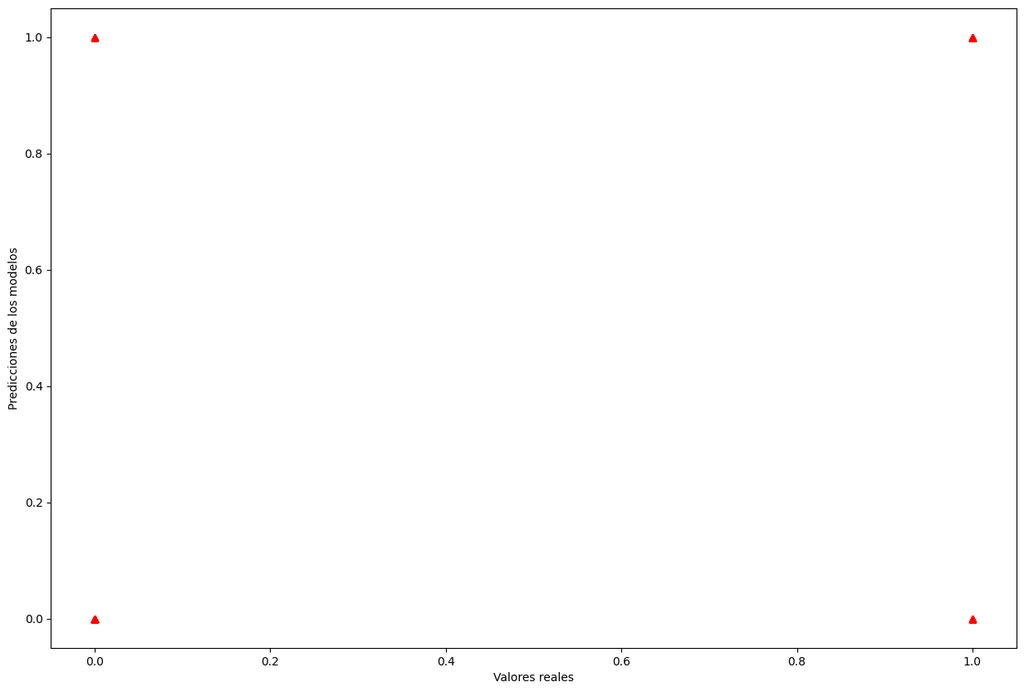

```python
y_predicc = predictor.predict(X_prueba)
plt.figure(figsize = (15, 10))
plt.plot(y_prueba, y_predicc, "^", color = 'r')
plt.ylabel('Predicciones de los modelos')
plt.xlabel('Valores reales')
```

```python
from sklearn.metrics import accuracy_score, confusion_matrix, classification_report

accuracy = accuracy_score(y_prueba, y_predicc)
confusion = confusion_matrix(y_prueba, y_predicc)
report = classification_report(y_prueba, y_predicc)

print(f"Accuracy: {accuracy:.3f}")
print("Confusion Matrix:\n", confusion)
print("Classification Report:\n", report)
```

```
Accuracy: 0.831
Confusion Matrix:
 [[96 11]
 [15 32]]
Classification Report:
               precision    recall  f1-score   support

           0       0.86      0.90      0.88       107
           1       0.74      0.68      0.71        47

    accuracy                           0.83       154
   macro avg       0.80      0.79      0.80       154
weighted avg       0.83      0.83      0.83       154
```

# Reflexion

Para esta semana, debido a la situacion del pais, fue un poco más difícil llevar la continuidad em virtual, ya que el foco de atención no es lo mismo en virtual que presencial Seguidamente el tema de AutoGluon, es muy interesante ya que es una herramienta que facilita y simplifica el proceso de construccion de modelos de aprendizaje automatico.

**Ventajas**

- Facilidad de uso: AutoGluon simplifica significativamente el proceso de modelado de aprendizaje automático al automatizar muchas tareas complejas, lo que lo hace accesible incluso para aquellos con poca experiencia en ciencia de datos.
- Optimización de hiperparámetros: Una de las características más útiles de AutoGluon es su capacidad para buscar de manera exhaustiva los mejores hiperparámetros para un modelo, lo que a menudo puede ser un proceso largo y complicado para los científicos de datos.
- Versatilidad: AutoGluon puede utilizarse para una variedad de tareas, incluyendo clasificación, regresión y modelado de series temporales, lo que lo convierte en una herramienta valiosa para una amplia gama de aplicaciones de aprendizaje automático.

**Desventajas**

- Falta de control personalizado: Aunque la automatización es beneficiosa, puede limitar la capacidad de los usuarios para realizar ajustes personalizados en el proceso de modelado, lo que podría ser un problema en aplicaciones más complejas que requieren un enfoque más específico.
- Poca transparencia en el proceso de modelado: Aunque AutoGluon ofrece resultados efectivos, la falta de transparencia en el proceso interno de modelado podría dificultar la comprensión de por qué un modelo en particular fue seleccionado o descartado.
- Requisitos de hardware y tiempo de ejecución: Algunos modelos generados por AutoGluon pueden requerir recursos computacionales significativos, lo que puede ser un obstáculo para aquellos con recursos limitados o restricciones de tiempo.